# Mobile_Price_Prediction

#### Project Title: **Estimation of Mobile Phone Pricing Through Machine Learning**

Project Overview:

In the fiercely competitive mobile phone industry, setting the right price for new products is crucial for success and sustainability. With major players like Apple and Samsung dominating the market, emerging companies face significant challenges in positioning their products attractively. This project aims to address the complexity of mobile phone pricing by harnessing the power of machine learning. Through an analytical approach, we intend to explore the relationship between mobile phone features, such as RAM and internal memory, and their selling price. Our goal is to define a price range, rather than pinpointing a specific price, to provide strategic insights into effective pricing strategies. This will enable our mobile company to make informed decisions, ensuring competitiveness and innovation in the market.

### Dataset:

Dataset columns are as follows:

- **id** - ID
- **battery_power** - Total energy a battery can store in one time measured in mAh
- **blue** - Has bluetooth or not
- **clock_speed** - Speed at which microprocessor executes instructions
- **dual_sim** - Has dual sim support or not
- **fc** - Front Camera mega pixels
- **four_g** - Has 4G or not
- **int_memory** - Internal Memory in Gigabytes
- **m_dep** - Mobile Depth in cm
- **mobile_wt** - Weight of mobile phone
- **n_cores** - Number of cores of processor
- **pc** - Primary Camera mega pixels
- **px_height** - Pixel Resolution Height
- **px_width** - Pixel Resolution Width
- **ram** - Random Access Memory in Megabytes
- **sc_h** - Screen Height of mobile in cm
- **sc_w** - Screen Width of mobile in cm
- **talk_time** - Longest time that a single battery charge will last when you are
- **three_g** - Has 3G or not
- **touch_screen** - Has touch screen or not
- **wifi** - Has wifi or not
- **price_range** - This is the target variable with value of:
  - 0 (low cost)
  - 1 (medium cost)
  - 2 (high cost)
  - 3 (very high cost)

### *Objectives*

- Exploring and Preprocessing Data
- Build different classification models to predict the mobile phone price range
- Price range prediction for 1000 usnseen data

### *Applied Models*

- Support Vector Machine (SVM)
- Decision Tree (DT)
- Random Forest (RF)
- XGBOOST (XGB)
- CATBOOST (CAT)
- Artificial Neural Network (ANN)

##### Importing required LIBRARIES

```python
import pandas as pd
import numpy as np
import matplotlib.pyplot as plt
import seaborn as sns
import math
from statistics import median
from sklearn.metrics import accuracy_score, confusion_matrix, recall_score, precision_score, f1_score, make_scorer
from sklearn.model_selection import GridSearchCV
from sklearn.model_selection import StratifiedKFold
from sklearn.model_selection import cross_val_score
from tabulate import tabulate
from sklearn.metrics import r2_score, mean_squared_error
from sklearn.preprocessing import PolynomialFeatures
import warnings
from sklearn.model_selection import train_test_split
from sklearn.decomposition import PCA
from sklearn.svm import SVC
from sklearn.tree import DecisionTreeClassifier
from sklearn.ensemble import RandomForestClassifier
import pickle
import xgboost as xgb
from catboost import CatBoostClassifier
from sklearn.preprocessing import StandardScaler
from tensorflow.keras.models import Sequential
from tensorflow.keras.layers import Dense
from tensorflow.keras.utils import to_categorical
from sklearn.pipeline import Pipeline
```

#### Importing the dataset

```python
df = pd.read_csv('train.csv')
```

## **Exploring the dataset**

```python
df.head()
```

|  | battery_power | blue | clock_speed | dual_sim | fc | four_g | int_memory | m_dep | mobile_wt | n_cores | ... | px_height | px_width | ram | sc_h | sc_w | talk_time | three_g | touch_screen | wifi | price_range |
| --- | --- | --- | --- | --- | --- | --- | --- | --- | --- | --- | --- | --- | --- | --- | --- | --- | --- | --- | --- | --- | --- |
| 0 | 842 | 0 | 2.2 | 0 | 1 | 0 | 7 | 0.6 | 188 | 2 | ... | 20 | 756 | 2549 | 9 | 7 | 19 | 0 | 0 | 1 | 1 |
| 1 | 1021 | 1 | 0.5 | 1 | 0 | 1 | 53 | 0.7 | 136 | 3 | ... | 905 | 1988 | 2631 | 17 | 3 | 7 | 1 | 1 | 0 | 2 |
| 2 | 563 | 1 | 0.5 | 1 | 2 | 1 | 41 | 0.9 | 145 | 5 | ... | 1263 | 1716 | 2603 | 11 | 2 | 9 | 1 | 1 | 0 | 2 |
| 3 | 615 | 1 | 2.5 | 0 | 0 | 0 | 10 | 0.8 | 131 | 6 | ... | 1216 | 1786 | 2769 | 16 | 8 | 11 | 1 | 0 | 0 | 2 |
| 4 | 1821 | 1 | 1.2 | 0 | 13 | 1 | 44 | 0.6 | 141 | 2 | ... | 1208 | 1212 | 1411 | 8 | 2 | 15 | 1 | 1 | 0 | 1 |

5 rows × 21 columns

```python
df.info()
```

```
<class 'pandas.core.frame.DataFrame'>
RangeIndex: 2000 entries, 0 to 1999
Data columns (total 21 columns):
 #   Column         Non-Null Count  Dtype
---  ------         --------------  -----
 0   battery_power  2000 non-null   int64
 1   blue           2000 non-null   int64
 2   clock_speed    2000 non-null   float64
 3   dual_sim       2000 non-null   int64
 4   fc             2000 non-null   int64
 5   four_g         2000 non-null   int64
 6   int_memory     2000 non-null   int64
 7   m_dep          2000 non-null   float64
 8   mobile_wt      2000 non-null   int64
 9   n_cores        2000 non-null   int64
 10  pc             2000 non-null   int64
 11  px_height      2000 non-null   int64
 12  px_width       2000 non-null   int64
 13  ram            2000 non-null   int64
 14  sc_h           2000 non-null   int64
 15  sc_w           2000 non-null   int64
 16  talk_time      2000 non-null   int64
 17  three_g        2000 non-null   int64
 18  touch_screen   2000 non-null   int64
 19  wifi           2000 non-null   int64
 20  price_range    2000 non-null   int64
dtypes: float64(2), int64(19)
memory usage: 328.2 KB
```

- This dataset contains information from **2000** mobile phones.
- We have **21 variables** including **20 independent variables** and **1 dependent variable** which is **price_range**.
- There is no **missing value** in the dataset.
- We have **8 categorical variables**: `n_cores` , `price_range`, `blue`, `dual_sim`, `four_g`, `three_g`, `touch_screen`, `wifi`
- We have **13 numeric variables**: `battery_power`, `clock_speed`, `fc`, `int_memory`, `m_dep`, `mobile_wt`, `pc`, `px_height`, `px_width`, `ram`, `talk_time`, `sc_h`, `sc_w`

#### FUNCTIONS

```python
def cat_uni_ana(df_categorical):
    n_features = df_categorical.shape[1]
    n_cols = 3
    n_rows = (n_features + n_cols - 1) // n_cols  # Ensures enough rows are created

    fig, axs = plt.subplots(n_rows, n_cols, figsize=(15, 15), subplot_kw=dict(aspect="equal"))
    for i, feature in enumerate(df_categorical.columns):
        row = i // n_cols
        col = i % n_cols
        value_counts = df_categorical[feature].value_counts()
        labels = value_counts.index.tolist()
        values = value_counts.values.tolist()
        cmap = plt.get_cmap('Oranges')
        colors = cmap(np.linspace(0.2, 0.8, len(labels)))
        axs[row, col].pie(values, labels=labels, autopct='%1.1f%%', startangle=140, colors=colors)
        axs[row, col].set_title(feature, fontsize=14)
    for ax in axs.flatten()[i+1:]:
        ax.axis('off')
    plt.tight_layout()
    plt.show()
    return None

def num_uni_ana(df_numerical):
    fig, ax = plt.subplots(nrows=5, ncols=3, figsize=(15,22))
    c = 'orangered'

    for i, col in enumerate(df_numerical.columns):
        x = i//3
        y = i%3
        values, bin_edges = np.histogram(df_numerical[col],
                                     range=(np.floor(df_numerical[col].min()), np.ceil(df_numerical[col].max())))
        graph = ax[x,y].hist(df_numerical[col], bins=bin_edges, color=c, alpha=0.6, edgecolor='none', linewidth=3, density=False)
        ax[x,y].set_xlabel(col, fontsize=15)
        ax[x,y].set_ylabel('Count', fontsize=12)
        ax[x,y].set_xticks(np.round(bin_edges,1))
        ax[x,y].set_xticklabels(np.round(bin_edges,1), rotation=45)
        ax[x,y].grid(color='lightgrey')
        for j, p in enumerate(graph[0]):
            ax[x,y].annotate('{}'.format(int(p)), (graph[1][j] + (graph[1][j+1] - graph[1][j]) / 2, p + 1),
                         ha='center', fontsize=10 ,fontweight="bold")
        textstr = '\n'.join((
        r'$\mu=%.2f$' %df_numerical[col].mean(),
       r'$\sigma=%.2f$' %df_numerical[col].std()
        ))
        ax[x,y].text(0.08, 0.2, textstr, transform=ax[x,y].transAxes, fontsize=10, verticalalignment='top',
                color='white', bbox=dict(boxstyle='round',facecolor='maroon', edgecolor='white', pad=0.5))

    ax[4, 1].axis('off')
    ax[4, 2].axis('off')
    plt.suptitle('Distribution of Numerical Variables', fontsize=20)
    plt.tight_layout()
    plt.subplots_adjust(top=0.95)
    plt.show()
    return None

# code


Table = []
Table_All = []
Table_All_c = []
Model = []
Score = []
best_model_score = 0
Accuracy = []
score_g = make_scorer(f1_score, average='weighted')
def save_model(model):
    model_name = model.__class__.__name__
    filename = f'{model_name}.pkl'
    with open(filename, 'wb') as file:
        pickle.dump(model, file)

def update_best_model(current_model, current_score, best_model, best_score):
    if current_score > best_score:
        best_model = current_model
        best_score = current_score
    return best_model, best_score

def grid(mdl, grid_search_param, X_train, y_train, X_val, y_val, score):
    warnings.filterwarnings("ignore")
    grid_search = GridSearchCV(mdl, grid_search_param, cv=5)
    grid_search.fit(X_train, y_train)
    best_model = grid_search.best_estimator_
    best_score = grid_search.best_score_
    best_param = grid_search.best_params_
    if score == True:
        y_pred_valt = grid_search.predict(X_val)
        score_val = f1_score(y_val, y_pred_valt, average='weighted')
    else:
        score_val = 0
        y_pred_valt = 0
    return best_model, best_score, best_param, y_pred_valt, score_val, grid_search

def featured_plot(best_clf, df):
    feature_importances = best_clf.feature_importances_
    feature_names = df.columns.tolist()
    sorted_indices = feature_importances.argsort()[::-1]
    plt.figure(figsize=(10, 6))
    plt.bar(range(len(feature_importances)), feature_importances[sorted_indices], align='center')
    plt.xticks(range(len(feature_importances)), [feature_names[i] for i in sorted_indices], rotation=45, ha='right')
    plt.xlabel('Features')
    plt.ylabel('Importance')
    plt.title('Feature Importances')
    plt.show()

def specificity_(cf):
    tn = cf[0][0]
    fn = cf[1][0]
    specificity = tn / (tn+fn)
    return specificity

def print_(data_type, cmatrix, train_accuracy, test_accuracy, recall, specificity, precision, false_positive_rate, f1, score):
    print(data_type, "Confusion Marix:\n", cmatrix)
    print(data_type, "Training accuracy:", train_accuracy)
    print(data_type, "Testing accuracy:", test_accuracy)
    print(data_type, "Recall (Sensitivity):", recall)
    print(data_type, "Specificity:", specificity)
    print(data_type, "Precision:", precision)
    print(data_type, "False Positive Rate:", false_positive_rate)
    print(data_type, "F1 Score:", f1)
    print(data_type, "Score:", score)
    print("#########################################################")
    return None

def test(y_pred, model, X_train, X_test, y_train, y_test, val):
    train_accuracy = accuracy_score(y_train, model.predict(X_train))
    test_accuracy = accuracy_score(y_test, y_pred)
    cmatrix = confusion_matrix(y_test, y_pred)
    recall = recall_score(y_test, y_pred, pos_label=1,average='weighted')
    specificity = specificity_(cmatrix)
    precision = precision_score(y_test, y_pred, average='weighted')
    false_positive_rate = 1 - specificity
    f1 = f1_score(y_test, y_pred, average='weighted')
    score = test_accuracy
    if val is False:
        print_("Test Data Set", cmatrix, train_accuracy, test_accuracy, recall, specificity, precision, false_positive_rate, f1, score)
    else:
        print_("Validation Data Set", cmatrix, train_accuracy, test_accuracy, recall, specificity, precision, false_positive_rate, f1, score)
    return cmatrix, train_accuracy, test_accuracy, recall, specificity, precision, false_positive_rate, f1, score

def print__(data_type, r2_train, rmse_train):
    print(data_type, "R^2", r2_train)
    print(data_type, "RMSE", rmse_train)
    print("#########################################################")
    return None

def test_(y_pred, model, X_train, X_test, y_train, y_test, val):
    #y_pred_train = model.predict(X_train)
    r2_train = r2_score(y_test, y_pred)
    mse_train = mean_squared_error(y_test, y_pred)
    rmse_train = np.sqrt(mse_train)
    if val is False:
        print__("Test Data Set", r2_train, rmse_train)
    else:
        print__("Validation Data Set", r2_train, rmse_train)
    return r2_train, rmse_train

#r2_train, rmse_train = model_L(X_train, X_test, y_train, y_test, model,  valid = None, X_val = X_val, y_val = y_val, nam = "LinearRegression")
def model_L(X_train, X_test, y_train, y_test, model, valid, X_val, y_val, nam):
    model.fit(X_train, y_train)
    y_pred = model.predict(X_test)
    r2_train, rmse_train = test_(y_pred, model, X_train, X_test, y_train, y_test, val = False)
    #Table.append([nam+'_Test_Data_Set', r2_train, rmse_train])
    Table_All.append([nam+'_Test_Data_Set', r2_train, rmse_train, model])
    y_val_pred = model.predict(X_val)
    r2_train, rmse_train = test_(y_val_pred, model, X_train, X_val, y_train = X_val, y_test = y_val, val = True)
    #Table.append([nam+'_VALIDATION_Data_Set', r2_train, rmse_train])
    Table_All.append([nam+'VALIDATION_Data_Set', r2_train, rmse_train, model])
    Model.append(model)
    #Score.append(score)
    if valid == 'CV':
        cv = StratifiedKFold(n_splits=5, shuffle=True, random_state=42)
        cv_scores = cross_val_score(model, X_train, y_train, cv=cv, scoring='accuracy')
    else:
        cv_scores = 0
    return  r2_train, rmse_train

def model_(X_train, X_test, y_train, y_test, model, valid, X_val, y_val, nam):
    model.fit(X_train, y_train)
    y_pred = model.predict(X_test)
    cmatrix, train_accuracy, test_accuracy, recall, specificity, precision, false_positive_rate, f1, score = test(y_pred, model, X_train, X_test, y_train, y_test, val = False)
    Table.append([nam+'_Test_Data_Set',model, score, recall, precision, f1 ])
    Table_All.append([nam+'_Test_Data_Set', score])
    y_val_pred = model.predict(X_val)
    cmatrix, train_accuracy, test_accuracy, recall, specificity, precision, false_positive_rate, f1, score = test(y_val_pred, model, X_train, X_val, y_train, y_val, val = True)
    Table.append([nam+'_VALIDATION_Data_Set',model, score, recall, precision, f1 ])
    Table_All.append([nam+'_VALIDATION_Data_Set', score])
    Model.append(model)
    Score.append(score)
    if valid == 'CV':
        cv = StratifiedKFold(n_splits=5, shuffle=True, random_state=42)
        cv_scores = cross_val_score(model, X_train, y_train, cv=cv, scoring='accuracy')
    else:
        cv_scores = 0
    return  cv_scores, score
```

## **Exploring Categorical Variables**

```python
df_categorical = df[['price_range', 'n_cores', 'blue', 'dual_sim', 'four_g', 'three_g', 'touch_screen', 'wifi']].astype(str)
unique_counts = df_categorical.nunique()
unique_values = df_categorical.apply(lambda x: x.unique())
pd.DataFrame({'Number of Unique Values': unique_counts, 'Unique Values': unique_values})
```

|  | Number of Unique Values | Unique Values |
| --- | --- | --- |
| price_range | 4 | [1, 2, 3, 0] |
| n_cores | 8 | [2, 3, 5, 6, 1, 8, 4, 7] |
| blue | 2 | [0, 1] |
| dual_sim | 2 | [0, 1] |
| four_g | 2 | [0, 1] |
| three_g | 2 | [0, 1] |
| touch_screen | 2 | [0, 1] |
| wifi | 2 | [1, 0] |

## **Exploring Numerical Variables**

```python
df_num = df.drop(df_categorical.columns, axis=1)
df_num.describe().T.round(1)
```

|  | count | mean | std | min | 25% | 50% | 75% | max |
| --- | --- | --- | --- | --- | --- | --- | --- | --- |
| battery_power | 2000.0 | 1238.5 | 439.4 | 501.0 | 851.8 | 1226.0 | 1615.2 | 1998.0 |
| clock_speed | 2000.0 | 1.5 | 0.8 | 0.5 | 0.7 | 1.5 | 2.2 | 3.0 |
| fc | 2000.0 | 4.3 | 4.3 | 0.0 | 1.0 | 3.0 | 7.0 | 19.0 |
| int_memory | 2000.0 | 32.0 | 18.1 | 2.0 | 16.0 | 32.0 | 48.0 | 64.0 |
| m_dep | 2000.0 | 0.5 | 0.3 | 0.1 | 0.2 | 0.5 | 0.8 | 1.0 |
| mobile_wt | 2000.0 | 140.2 | 35.4 | 80.0 | 109.0 | 141.0 | 170.0 | 200.0 |
| pc | 2000.0 | 9.9 | 6.1 | 0.0 | 5.0 | 10.0 | 15.0 | 20.0 |
| px_height | 2000.0 | 645.1 | 443.8 | 0.0 | 282.8 | 564.0 | 947.2 | 1960.0 |
| px_width | 2000.0 | 1251.5 | 432.2 | 500.0 | 874.8 | 1247.0 | 1633.0 | 1998.0 |
| ram | 2000.0 | 2124.2 | 1084.7 | 256.0 | 1207.5 | 2146.5 | 3064.5 | 3998.0 |
| sc_h | 2000.0 | 12.3 | 4.2 | 5.0 | 9.0 | 12.0 | 16.0 | 19.0 |
| sc_w | 2000.0 | 5.8 | 4.4 | 0.0 | 2.0 | 5.0 | 9.0 | 18.0 |
| talk_time | 2000.0 | 11.0 | 5.5 | 2.0 | 6.0 | 11.0 | 16.0 | 20.0 |

## **Categorial Univariate Analysis**

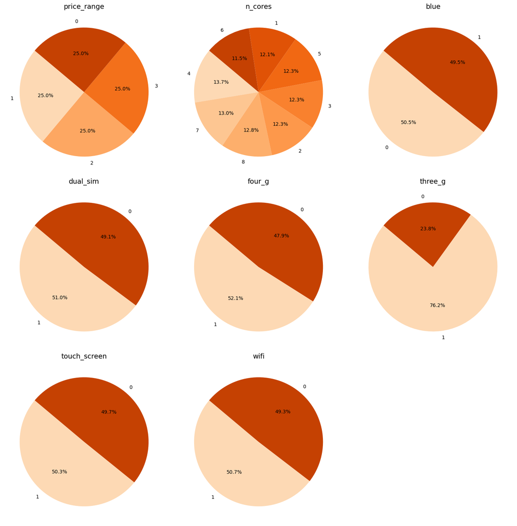

```python
cat_uni_ana(df_categorical=df_categorical)
```

- The dataset exhibits an equal distribution of mobile phones across all four price_range categories, indicating a **perfectly balanced dataset**.
- The occurrence of features such as Bluetooth, 4G connectivity, touch screen capability, Wifi support, dual SIM functionality, and the count of processing cores is uniformly distributed among the mobile phones in the dataset.
- Approximately 76% of the mobile phones in the dataset are equipped with 3G support.

## **Numerical Univariate Analysis**

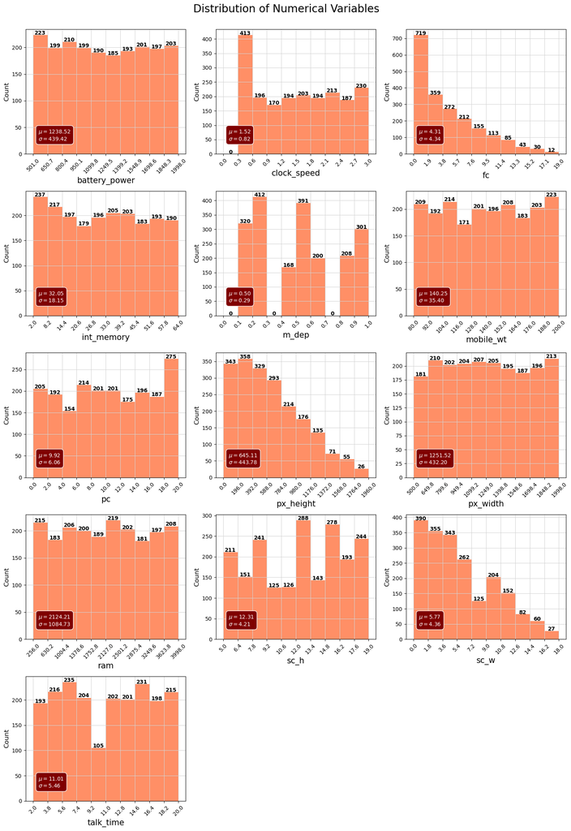

```python
num_uni_ana(df_num)
```

- The graphical representations above facilitate a straightforward comprehension of the statistical characteristics for each attribute, covering their minimum and maximum, along with the mean and standard deviation.
- Notably, within certain attributes such as px_height (Pixel Resolution Height) and sc_w (Screen Width of mobile in cm), a substantial number of values approaching zero are noticeable, which might be considered as noise. However, it's unlikely that these will significantly impact the predictive models.

# **Feature Selection**

#### *Pearson Correlation*

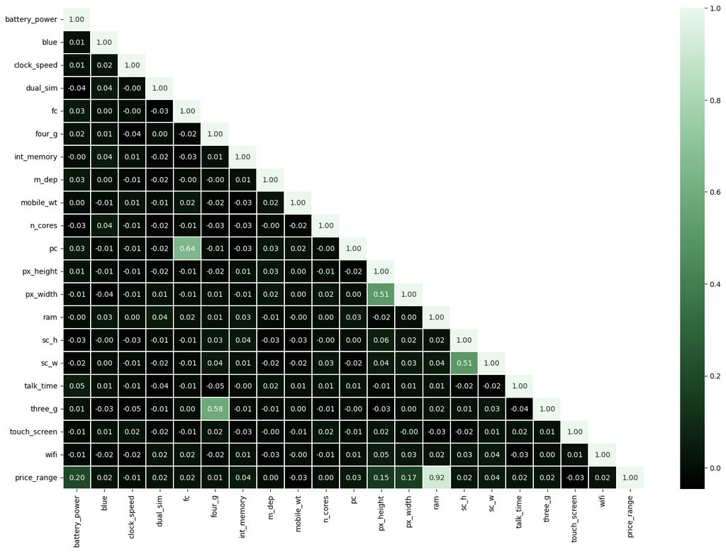

```python
cp = sns.cubehelix_palette(start=2, rot=0, dark=0, light=.95, reverse=True, as_cmap=True)

# Calculation of the Spearman correlation
target = 'price_range'
df_ordered = pd.concat([df.drop(target,axis=1), df[target]],axis=1)
corr = df_ordered.corr()

# Create a mask so that we see the correlation values only once
mask = np.zeros_like(corr)
mask[np.triu_indices_from(mask,1)] = True

# Plot the heatmap correlation
plt.figure(figsize=(18,12))
sns.heatmap(corr, mask=mask, cmap=cp, annot=True, fmt='.2f', linewidths=0.2)
plt.show()
```

- `price_range` is highly correlated with `ram` (ρ = 0.92).
- The `price_range` variable displays minimal correlation with other attributes; however, this low correlation coefficient should not be a basis for excluding these features, as the Pearson correlation specifically quantifies the linear association between two variables.
- Within the dataset, the features pc (Primary Camera) and fc (Front Camera) exhibit the strongest correlation to each other, with a **correlation coefficient (ρ) of 0.64.**

# **MODEL BUILDING**

##### Splitting train and test data

```python
X = df.drop('price_range',axis=1)
y = df['price_range']
X_train, X_test, y_train, y_test = train_test_split(X, y, test_size=0.40, random_state=42)
X_val, X_test, y_val, y_test = train_test_split(X_test, y_test, test_size=0.50, random_state=42)
```

#### PCA SCALING

```python
pca = PCA(n_components=None)
pca.fit(X_train)
X_train_pca = pca.transform(X_train)
X_val_pca = pca.transform(X_val)
X_test_pca = pca.transform(X_test)
```

```
[0.66742278 0.8321589  0.94444127 0.99902314 0.999735   0.99992593
 0.99995239 0.99996997 0.99998547 0.99999085 0.99999573 0.99999875
 0.99999914 0.99999934 0.99999948 0.99999963 0.99999977 0.99999991
 0.99999995 1.        ]
```

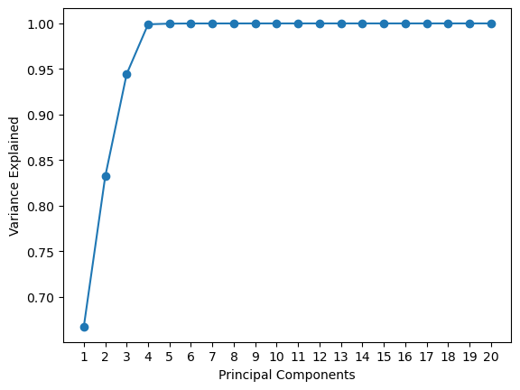

```python
print(pca.explained_variance_ratio_.cumsum())
plt.plot(pca.explained_variance_ratio_.cumsum(), '-o')
plt.xticks(ticks= range(X_train_pca.shape[1]), labels=[i+1 for i in range(X_train_pca.shape[1])])
plt.xlabel('Principal Components')
plt.ylabel('Variance Explained')
plt.show()
```

#### **SVM CLASSIFIER**

```python
model = SVC(probability=True, random_state=0)
model_(X_train, X_test, y_train, y_test, model=model,  valid = None, X_val = X_val, y_val = y_val, nam = "SVC CLASSIFIER")
```

```
Test Data Set Confusion Marix:
 [[106   2   0   0]
 [  1  94   1   0]
 [  0   5  92   6]
 [  0   0   2  91]]
Test Data Set Training accuracy: 0.945
Test Data Set Testing accuracy: 0.9575
Test Data Set Recall (Sensitivity): 0.9575
Test Data Set Specificity: 0.9906542056074766
Test Data Set Precision: 0.9583299499013447
Test Data Set False Positive Rate: 0.009345794392523366
Test Data Set F1 Score: 0.9572715467431775
Test Data Set Score: 0.9575
#########################################################
Validation Data Set Confusion Marix:
 [[ 91   3   0   0]
 [  0  97   1   0]
 [  0   6  87   6]
 [  0   0   6 103]]
Validation Data Set Training accuracy: 0.945
Validation Data Set Testing accuracy: 0.945
Validation Data Set Recall (Sensitivity): 0.945
Validation Data Set Specificity: 1.0
Validation Data Set Precision: 0.9457672621437174
Validation Data Set False Positive Rate: 0.0
Validation Data Set F1 Score: 0.9448141002935273
Validation Data Set Score: 0.945
#########################################################
```

```
(0, 0.945)
```

#### *SVM CLASSIFIER WITH PCA*

```python
model = SVC(probability=True, random_state=0)
model_(X_train_pca, X_test_pca, y_train, y_test, model=model,  valid = None, X_val = X_val_pca, y_val = y_val, nam = "SVM CLASSIFIER PCA")
```

```
Test Data Set Confusion Marix:
 [[104   4   0   0]
 [  2  94   0   0]
 [  0   5  94   4]
 [  0   0   4  89]]
Test Data Set Training accuracy: 0.9591666666666666
Test Data Set Testing accuracy: 0.9525
Test Data Set Recall (Sensitivity): 0.9525
Test Data Set Specificity: 0.9811320754716981
Test Data Set Precision: 0.9534245825093179
Test Data Set False Positive Rate: 0.018867924528301883
Test Data Set F1 Score: 0.9525093460280432
Test Data Set Score: 0.9525
#########################################################
```

```
Validation Data Set Confusion Marix:
 [[ 91   3   0   0]
 [  0  98   0   0]
 [  0   5  90   4]
 [  0   0   5 104]]
Validation Data Set Training accuracy: 0.9591666666666666
Validation Data Set Testing accuracy: 0.9575
Validation Data Set Recall (Sensitivity): 0.9575
Validation Data Set Specificity: 1.0
Validation Data Set Precision: 0.9583905255801978
Validation Data Set False Positive Rate: 0.0
Validation Data Set F1 Score: 0.9574186779916939
Validation Data Set Score: 0.9575
#########################################################
```

```
(0, 0.9575)
```

#### *SVM CLASSIFIER WITH HYPERPARAMETERS WITH PCA*

```python
grid_search_param = [{'kernel': ['poly'],
               'degree': [2, 3, 4, 5],
               'gamma': [1, 0.1, 0.01, 0.001, 0.0001],
               'C': [0.01, 0.1, 1, 10, 100, 1000]},

              {'kernel': ['rbf','sigmoid'],
               'gamma': [1, 0.1, 0.01, 0.001, 0.0001],
               'C': [0.01, 0.1, 1, 10, 100, 1000]},

              {'kernel': ['linear'],
               'C': [0.01, 0.1, 1, 10, 50, 100, 1000]}
             ]
model = SVC()
```

```python
grid_search_param = [{'kernel': ['linear'], 'C':[50]}]
#### this hyperparametere find took 522 minutes to find. So, I'm defining it here.
```

```python
best_model, best_score, best_param, y_pred_valt, score_val, grid_search = grid(model, grid_search_param, X_train_pca, y_train, X_val = X_val_pca, y_val = y_val, score= True)
cv_scores, scr = model_(X_train_pca, X_test_pca, y_train, y_test, best_model, valid = None, X_val = X_val_pca, y_val = y_val, nam = "SVC CLASSIFIER GRID PCA ")
```

```
Test Data Set Confusion Marix:
 [[105   3   0   0]
 [  1  95   0   0]
 [  0   4  99   0]
 [  0   0   5  88]]
Test Data Set Training accuracy: 1.0
Test Data Set Testing accuracy: 0.9675
Test Data Set Recall (Sensitivity): 0.9675
Test Data Set Specificity: 0.9905660377358491
Test Data Set Precision: 0.9686024342610774
Test Data Set False Positive Rate: 0.009433962264150941
Test Data Set F1 Score: 0.967637997223453
Test Data Set Score: 0.9675
#########################################################
Validation Data Set Confusion Marix:
 [[ 92   2   0   0]
 [  0  96   2   0]
 [  0   3  94   2]
 [  0   0   2 107]]
Validation Data Set Training accuracy: 1.0
Validation Data Set Testing accuracy: 0.9725
Validation Data Set Recall (Sensitivity): 0.9725
Validation Data Set Specificity: 1.0
Validation Data Set Precision: 0.9727692463123863
Validation Data Set False Positive Rate: 0.0
Validation Data Set F1 Score: 0.9725479212283239
Validation Data Set Score: 0.9725
#########################################################
```

```python
svc_bst_md = best_model
save_model(svc_bst_md)
```

#### **DECISION TREE CLASSIFIER**

```python
model = DecisionTreeClassifier(random_state=0)
model_(X_train, X_test, y_train, y_test, model=model,  valid = None, X_val = X_val, y_val = y_val, nam = "Decision Tree CLASSIFIER")
```

```
Test Data Set Confusion Marix:
 [[95 13  0  0]
 [10 79  7  0]
 [ 0 10 80 13]
 [ 0  0 13 80]]
Test Data Set Training accuracy: 1.0
Test Data Set Testing accuracy: 0.835
Test Data Set Recall (Sensitivity): 0.835
Test Data Set Specificity: 0.9047619047619048
Test Data Set Precision: 0.8361680672268907
Test Data Set False Positive Rate: 0.09523809523809523
Test Data Set F1 Score: 0.8353158869623174
Test Data Set Score: 0.835
#########################################################
Validation Data Set Confusion Marix:
 [[75 19  0  0]
 [14 73 10  1]
 [ 0 12 70 17]
 [ 0  0 13 96]]
Validation Data Set Training accuracy: 1.0
Validation Data Set Testing accuracy: 0.785
Validation Data Set Recall (Sensitivity): 0.785
Validation Data Set Specificity: 0.8426966292134831
Validation Data Set Precision: 0.7857688685024938
Validation Data Set False Positive Rate: 0.1573033707865169
Validation Data Set F1 Score: 0.7847897428211817
Validation Data Set Score: 0.785
#########################################################
```

```
(0, 0.785)
```

#### *Decision tree classifier with PCA*

```python
model_(X_train_pca, X_test_pca, y_train, y_test, model=model,  valid = None, X_val = X_val_pca, y_val = y_val, nam = "Decision Tree CLASSIFIER PCA")
```

```
Test Data Set Confusion Marix:
 [[90 18  0  0]
 [ 8 79  9  0]
 [ 0 11 78 14]
 [ 0  0 17 76]]
Test Data Set Training accuracy: 1.0
Test Data Set Testing accuracy: 0.8075
Test Data Set Recall (Sensitivity): 0.8075
Test Data Set Specificity: 0.9183673469387755
Test Data Set Precision: 0.8129730725623583
Test Data Set False Positive Rate: 0.08163265306122447
Test Data Set F1 Score: 0.8089774081511173
Test Data Set Score: 0.8075
#########################################################
Validation Data Set Confusion Marix:
 [[78 16  0  0]
 [ 6 86  6  0]
 [ 0  9 72 18]
 [ 0  0 12 97]]
Validation Data Set Training accuracy: 1.0
Validation Data Set Testing accuracy: 0.8325
Validation Data Set Recall (Sensitivity): 0.8325
Validation Data Set Specificity: 0.9285714285714286
Validation Data Set Precision: 0.8358819316210621
Validation Data Set False Positive Rate: 0.0714285714285714
Validation Data Set F1 Score: 0.8321577432952914
Validation Data Set Score: 0.8325
#########################################################
```

```
(0, 0.8325)
```

#### *Decision tree Hyperparameter Tuning*

```python
grid_search_param = {'criterion': ['gini', 'entropy', 'log_loss'],
              'max_depth': np.arange(1, 15),
              'min_samples_split': np.arange(2, 10),
              'min_samples_leaf': np.arange(1, 10),
              'max_features': [None, 'sqrt', 'log2']}
```

###### The below parameter is a best model which are found in grid search by using above hyperparameters. Due to high runtime, the best model params are fed into the model.

```python
grid_search_param = {'criterion': ['gini'], 'max_depth': [9], 'max_features': [None], 'min_samples_leaf': [3], 'min_samples_split': [8]}
```

```python
best_model, best_score, best_param, y_pred_valt, score_val, grid_search = grid(model, grid_search_param, X_train_pca, y_train, X_val = X_val_pca, y_val = y_val, score= True)
cv_scores, scr = model_(X_train_pca, X_test_pca, y_train, y_test, best_model, valid = None, X_val = X_val_pca, y_val = y_val, nam = "Decision Tree CLASSIFIER GRID PCA ")
```

```
Test Data Set Confusion Marix:
 [[100   8   0   0]
 [ 13  74   9   0]
 [  0  13  79  11]
 [  0   0  12  81]]
Test Data Set Training accuracy: 0.9625
Test Data Set Testing accuracy: 0.835
Test Data Set Recall (Sensitivity): 0.835
Test Data Set Specificity: 0.8849557522123894
Test Data Set Precision: 0.8340115084749194
Test Data Set False Positive Rate: 0.11504424778761058
Test Data Set F1 Score: 0.8343257915965667
Test Data Set Score: 0.835
#########################################################
Validation Data Set Confusion Marix:
 [[ 81  13   0   0]
 [ 12  78   8   0]
 [  0  10  74  15]
 [  0   0   9 100]]
Validation Data Set Training accuracy: 0.9625
Validation Data Set Testing accuracy: 0.8325
Validation Data Set Recall (Sensitivity): 0.8325
Validation Data Set Specificity: 0.8709677419354839
Validation Data Set Precision: 0.8321055981497847
Validation Data Set False Positive Rate: 0.12903225806451613
Validation Data Set F1 Score: 0.8317362343208543
Validation Data Set Score: 0.8325
#########################################################
```

```python
dt_bst_mdl = best_model
save_model(dt_bst_mdl)
```

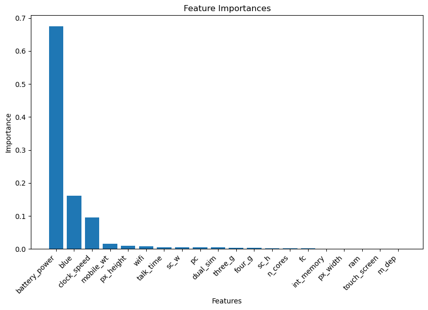

```python
featured_plot(best_model, df)
```

```python
rf = RandomForestClassifier(criterion='gini', max_features=None, bootstrap=True, random_state=0)
model_(X_train, X_test, y_train, y_test, model=model,  valid = None, X_val = X_val, y_val = y_val, nam = "Random Forest CLASSIFIER")
```

```
Test Data Set Confusion Marix:
 [[95 13  0  0]
 [10 79  7  0]
 [ 0 10 80 13]
 [ 0  0 13 80]]
Test Data Set Training accuracy: 1.0
Test Data Set Testing accuracy: 0.835
Test Data Set Recall (Sensitivity): 0.835
Test Data Set Specificity: 0.9047619047619048
Test Data Set Precision: 0.8361680672268907
Test Data Set False Positive Rate: 0.09523809523809523
Test Data Set F1 Score: 0.8353158869623174
Test Data Set Score: 0.835
#########################################################
Validation Data Set Confusion Marix:
 [[75 19  0  0]
 [14 73 10  1]
 [ 0 12 70 17]
 [ 0  0 13 96]]
Validation Data Set Training accuracy: 1.0
Validation Data Set Testing accuracy: 0.785
Validation Data Set Recall (Sensitivity): 0.785
Validation Data Set Specificity: 0.8426966292134831
Validation Data Set Precision: 0.7857688685024938
Validation Data Set False Positive Rate: 0.1573033707865169
Validation Data Set F1 Score: 0.7847897428211817
Validation Data Set Score: 0.785
#########################################################
```

```
(0, 0.785)
```

#### *Random Forest with PCA*

```python
model_(X_train_pca, X_test_pca, y_train, y_test, model=model,  valid = None, X_val = X_val_pca, y_val = y_val, nam = "Random Forest CLASSIFIER")
```

```
Test Data Set Confusion Marix:
 [[90 18  0  0]
 [ 8 79  9  0]
 [ 0 11 78 14]
 [ 0  0 17 76]]
Test Data Set Training accuracy: 1.0
Test Data Set Testing accuracy: 0.8075
Test Data Set Recall (Sensitivity): 0.8075
Test Data Set Specificity: 0.9183673469387755
Test Data Set Precision: 0.8129730725623583
Test Data Set False Positive Rate: 0.08163265306122447
Test Data Set F1 Score: 0.8089774081511173
Test Data Set Score: 0.8075
#########################################################
Validation Data Set Confusion Marix:
 [[78 16  0  0]
 [ 6 86  6  0]
 [ 0  9 72 18]
 [ 0  0 12 97]]
Validation Data Set Training accuracy: 1.0
Validation Data Set Testing accuracy: 0.8325
Validation Data Set Recall (Sensitivity): 0.8325
Validation Data Set Specificity: 0.9285714285714286
Validation Data Set Precision: 0.8358819316210621
Validation Data Set False Positive Rate: 0.0714285714285714
Validation Data Set F1 Score: 0.8321577432952914
Validation Data Set Score: 0.8325
#########################################################
```

```
(0, 0.8325)
```

#### *Random Forest HYPERTUNING*

```python
grid_search_param = {
    'criterion': ['gini', 'entropy', 'log_loss'],
    'max_depth': np.arange(10, 18),
    'min_samples_split': [2, 3, 4],
    'min_samples_leaf': [1, 2, 3]
}
```

###### The below parameter is a best model which are found in grid search by using above hyperparameters. Due to high runtime, the best model params are fed into the model.

```python
grid_search_param = {'max_depth': [14], 'min_samples_leaf': [1], 'min_samples_split': [2], 'criterion': ['gini']}
```

```python
best_model, best_score, best_param, y_pred_valt, score_val, grid_search = grid(model, grid_search_param, X_train_pca, y_train, X_val = X_val_pca, y_val = y_val, score= True)
model_(X_train_pca, X_test_pca, y_train, y_test, model=model,  valid = None, X_val = X_val_pca, y_val = y_val, nam = "Random Forest CLASSIFIER GRID PCA")
```

```
Test Data Set Confusion Marix:
 [[90 18  0  0]
 [ 8 79  9  0]
 [ 0 11 78 14]
 [ 0  0 17 76]]
Test Data Set Training accuracy: 1.0
Test Data Set Testing accuracy: 0.8075
Test Data Set Recall (Sensitivity): 0.8075
Test Data Set Specificity: 0.9183673469387755
Test Data Set Precision: 0.8129730725623583
Test Data Set False Positive Rate: 0.08163265306122447
Test Data Set F1 Score: 0.8089774081511173
Test Data Set Score: 0.8075
#########################################################
Validation Data Set Confusion Marix:
 [[78 16  0  0]
 [ 6 86  6  0]
 [ 0  9 72 18]
 [ 0  0 12 97]]
Validation Data Set Training accuracy: 1.0
Validation Data Set Testing accuracy: 0.8325
Validation Data Set Recall (Sensitivity): 0.8325
Validation Data Set Specificity: 0.9285714285714286
Validation Data Set Precision: 0.8358819316210621
Validation Data Set False Positive Rate: 0.0714285714285714
Validation Data Set F1 Score: 0.8321577432952914
Validation Data Set Score: 0.8325
#########################################################
```

```
(0, 0.8325)
```

```python
rdm_bst_mdl = best_model
save_model(rdm_bst_mdl)
```

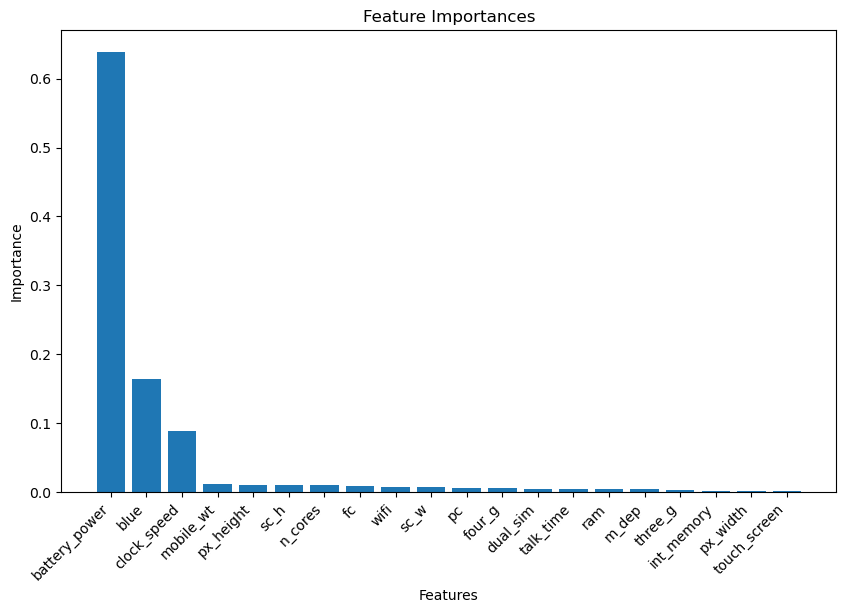

```python
featured_plot(best_model, df)
```

#### **XGBOOST CLASSIFIER****

```python
model = xgb.XGBClassifier(n_estimators=100,
                                  learning_rate=0.1,
                                  max_depth=3,
                                  use_label_encoder=False,
                                  eval_metric='mlogloss')
model_(X_train, X_test, y_train, y_test, model=model,  valid = None, X_val = X_val, y_val = y_val, nam = "XGBOOST CLASSIFIER")
```

```
Test Data Set Confusion Marix:
 [[102   6   0   0]
 [  7  83   6   0]
 [  0  12  82   9]
 [  0   0   9  84]]
Test Data Set Training accuracy: 0.9908333333333333
Test Data Set Testing accuracy: 0.8775
Test Data Set Recall (Sensitivity): 0.8775
Test Data Set Specificity: 0.9357798165137615
Test Data Set Precision: 0.877568685602127
Test Data Set False Positive Rate: 0.06422018348623848
Test Data Set F1 Score: 0.8772083873306978
Test Data Set Score: 0.8775
#########################################################
Validation Data Set Confusion Marix:
 [[ 89   5   0   0]
 [  8  87   3   0]
 [  0   9  78  12]
 [  0   0   7 102]]
Validation Data Set Training accuracy: 0.9908333333333333
Validation Data Set Testing accuracy: 0.89
Validation Data Set Recall (Sensitivity): 0.89
Validation Data Set Specificity: 0.9175257731958762
Validation Data Set Precision: 0.8898489501351112
Validation Data Set False Positive Rate: 0.08247422680412375
Validation Data Set F1 Score: 0.8889794405757888
Validation Data Set Score: 0.89
#########################################################
```

```
(0, 0.89)
```

### *XGBOOST WITH PCA SCALING*

```python
model_(X_train_pca, X_test_pca, y_train, y_test, model=model,  valid = None, X_val = X_val_pca, y_val = y_val, nam = "XGBOOST CLASSIFIER PCA")
```

```
Test Data Set Confusion Marix:
 [[99  9  0  0]
 [ 5 85  6  0]
 [ 0 10 86  7]
 [ 0  0 14 79]]
Test Data Set Training accuracy: 0.995
Test Data Set Testing accuracy: 0.8725
Test Data Set Recall (Sensitivity): 0.8725
Test Data Set Specificity: 0.9519230769230769
Test Data Set Precision: 0.8756637526580485
Test Data Set False Positive Rate: 0.04807692307692313
Test Data Set F1 Score: 0.8733071506059917
Test Data Set Score: 0.8725
#########################################################
Validation Data Set Confusion Marix:
 [[ 88   6   0   0]
 [  4  91   3   0]
 [  0   9  82   8]
 [  0   0   8 101]]
Validation Data Set Training accuracy: 0.995
Validation Data Set Testing accuracy: 0.905
Validation Data Set Recall (Sensitivity): 0.905
Validation Data Set Specificity: 0.9565217391304348
Validation Data Set Precision: 0.9058386038265104
Validation Data Set False Positive Rate: 0.04347826086956519
Validation Data Set F1 Score: 0.9048502727703984
Validation Data Set Score: 0.905
#########################################################
```

```
(0, 0.905)
```

#### *XGBOOST HYPERPARAMETER*

```python
params = {
    'objective': 'multi:softmax',  # For multiclass classification
    'num_class': 3,  # Number of classes in the dataset
    'max_depth': 3,
    'eta': 0.1,
    'subsample': 0.7,
    'colsample_bytree': 0.7
}
```

```python
model = xgb.XGBClassifier(params)
model_(X_train_pca, X_test_pca, y_train, y_test, model=model,  valid = None, X_val = X_val_pca, y_val = y_val, nam = "XGBOOST CLASSIFIER PCA HYPE")
```

```
Test Data Set Confusion Marix:
 [[101   7   0   0]
 [  5  88   3   0]
 [  0  10  86   7]
 [  0   0   6  87]]
Test Data Set Training accuracy: 1.0
Test Data Set Testing accuracy: 0.905
Test Data Set Recall (Sensitivity): 0.905
Test Data Set Specificity: 0.9528301886792453
Test Data Set Precision: 0.9066984414569141
Test Data Set False Positive Rate: 0.047169811320754707
Test Data Set F1 Score: 0.9050328338980461
Test Data Set Score: 0.905
#########################################################
Validation Data Set Confusion Marix:
 [[ 89   5   0   0]
 [  4  89   5   0]
 [  0  10  82   7]
 [  0   0   7 102]]
Validation Data Set Training accuracy: 1.0
Validation Data Set Testing accuracy: 0.905
Validation Data Set Recall (Sensitivity): 0.905
Validation Data Set Specificity: 0.956989247311828
Validation Data Set Precision: 0.9054601899758902
Validation Data Set False Positive Rate: 0.043010752688172005
Validation Data Set F1 Score: 0.9048918095101189
Validation Data Set Score: 0.905
#########################################################
```

```
(0, 0.905)
```

```python
xgb_bst_mdl = model
save_model(xgb_bst_mdl)
```

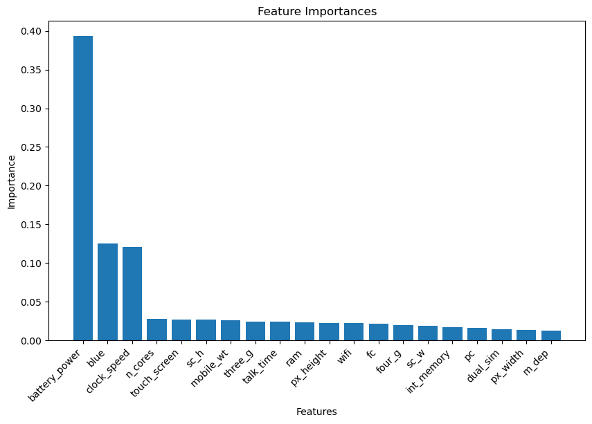

```python
featured_plot(model, df)
```

### **CATBOOST CLASSIFIER**

```python
model = CatBoostClassifier(iterations=100,
                                    learning_rate=0.1,
                                    depth=3,
                                    loss_function='MultiClass',
                                    verbose=False)
model_(X_train, X_test, y_train, y_test, model=model,  valid = None, X_val = X_val, y_val = y_val, nam = "CATBOOST CLASSIFIER")
```

```
Test Data Set Confusion Marix:
 [[105   3   0   0]
 [  5  84   7   0]
 [  0   9  87   7]
 [  0   0   8  85]]
Test Data Set Training accuracy: 0.9308333333333333
Test Data Set Testing accuracy: 0.9025
Test Data Set Recall (Sensitivity): 0.9025
Test Data Set Specificity: 0.9545454545454546
Test Data Set Precision: 0.9021694082771448
Test Data Set False Positive Rate: 0.045454545454545414
Test Data Set F1 Score: 0.9023013673776709
Test Data Set Score: 0.9025
#########################################################
Validation Data Set Confusion Marix:
 [[91  3  0  0]
 [ 6 90  2  0]
 [ 0  6 83 10]
 [ 0  0 10 99]]
Validation Data Set Training accuracy: 0.9308333333333333
Validation Data Set Testing accuracy: 0.9075
Validation Data Set Recall (Sensitivity): 0.9075
Validation Data Set Specificity: 0.9381443298969072
Validation Data Set Precision: 0.9069280323583091
Validation Data Set False Positive Rate: 0.061855670103092786
Validation Data Set F1 Score: 0.9070629201064492
Validation Data Set Score: 0.9075
#########################################################
```

```
(0, 0.9075)
```

### *CATBOOST WITH PCA*

```python
model_(X_train_pca, X_test_pca, y_train, y_test, model=model,  valid = None, X_val = X_val_pca, y_val = y_val, nam = "CATBOOST CLASSIFIER PCA")
```

```
Test Data Set Confusion Marix:
 [[102   6   0   0]
 [  5  87   4   0]
 [  0   8  85  10]
 [  0   0   9  84]]
Test Data Set Training accuracy: 0.93
Test Data Set Testing accuracy: 0.895
Test Data Set Recall (Sensitivity): 0.895
Test Data Set Specificity: 0.9532710280373832
Test Data Set Precision: 0.8952236450189226
Test Data Set False Positive Rate: 0.04672897196261683
Test Data Set F1 Score: 0.8948288169424349
Test Data Set Score: 0.895
#########################################################
Validation Data Set Confusion Marix:
 [[90  4  0  0]
 [ 6 89  3  0]
 [ 0  9 80 10]
 [ 0  0 10 99]]
Validation Data Set Training accuracy: 0.93
Validation Data Set Testing accuracy: 0.895
Validation Data Set Recall (Sensitivity): 0.895
Validation Data Set Specificity: 0.9375
Validation Data Set Precision: 0.8944902356103731
Validation Data Set False Positive Rate: 0.0625
Validation Data Set F1 Score: 0.8944315789473685
Validation Data Set Score: 0.895
#########################################################
```

```
(0, 0.895)
```

#### *CATBOOST WITH HYPER PARAMETERS*

```python
iterations = 500
learning_rate = 0.1
depth = 6
l2_leaf_reg = 3
loss_function = 'MultiClass'
eval_metric = 'Accuracy'
random_seed = 42
```

```python
model = CatBoostClassifier(iterations=iterations,
                                    learning_rate=learning_rate,
                                    depth=depth,
                                    l2_leaf_reg=l2_leaf_reg,
                                    loss_function=loss_function,
                                    eval_metric=eval_metric,
                                    random_seed=random_seed)
model_(X_train_pca, X_test_pca, y_train, y_test, model=model,  valid = None, X_val = X_val_pca, y_val = y_val, nam = "CATBOOST CLASSIFIER PCA")
```

[output not shown]

[output not shown]

[output cut: 443 more lines]

```
#########################################################
Validation Data Set Confusion Marix:
 [[ 90   4   0   0]
 [  2  94   2   0]
 [  0   7  87   5]
 [  0   0   7 102]]
Validation Data Set Training accuracy: 1.0
Validation Data Set Testing accuracy: 0.9325
Validation Data Set Recall (Sensitivity): 0.9325
Validation Data Set Specificity: 0.9782608695652174
Validation Data Set Precision: 0.9332878678213464
Validation Data Set False Positive Rate: 0.021739130434782594
Validation Data Set F1 Score: 0.9325231715201125
Validation Data Set Score: 0.9325
#########################################################
```

```
(0, 0.9325)
```

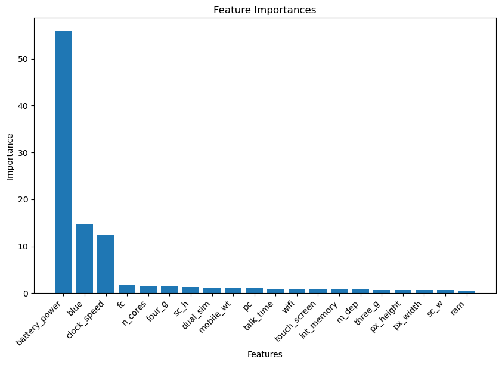

```python
featured_plot(model, df)
```

```python
cat_bst_mdl = model
save_model(cat_bst_mdl)
```

#### **ARTIFICIAL NEURAL NETWORK**

```python
scaler = StandardScaler()
X_train_scaled = scaler.fit_transform(X_train)
X_val_scaled = scaler.transform(X_val)

y_train_cat = to_categorical(y_train)
y_val_cat = to_categorical(y_val)

model = Sequential([
    Dense(64, activation='relu', input_shape=(X_train_scaled.shape[1],)),
    Dense(64, activation='relu'),
    Dense(4, activation='softmax')
])

model.compile(optimizer='adam', loss='categorical_crossentropy', metrics=['accuracy'])
history = model.fit(X_train_scaled, y_train_cat, validation_data=(X_val_scaled, y_val_cat), epochs=100, batch_size=32, verbose=0)
val_accuracy = history.history['val_accuracy'][-1]
val_loss = history.history['val_loss'][-1]

Model.append(model)
Score.append(val_accuracy)
```

```python
(val_accuracy, val_loss)
```

```
(0.8974999785423279, 0.34246373176574707)
```

# **Conclusion and Summary**

```python
tab = tabulate(Table_All, headers=["Model", "Score"], tablefmt='fancy_grid')
df = pd.DataFrame(Table_All, columns =['Model Name', 'Score'])
```

```python
sort = df.sort_values("Score", ascending=False)
display(sort.iloc[:8])
```

[output not shown]

[output not shown]

### **Let's check with the realtime data**

```python
df_t = pd.read_csv('test.csv')
df_t.head(5)
```

|  | id | battery_power | blue | clock_speed | dual_sim | fc | four_g | int_memory | m_dep | mobile_wt | ... | pc | px_height | px_width | ram | sc_h | sc_w | talk_time | three_g | touch_screen | wifi |
| --- | --- | --- | --- | --- | --- | --- | --- | --- | --- | --- | --- | --- | --- | --- | --- | --- | --- | --- | --- | --- | --- |
| 0 | 1 | 1043 | 1 | 1.8 | 1 | 14 | 0 | 5 | 0.1 | 193 | ... | 16 | 226 | 1412 | 3476 | 12 | 7 | 2 | 0 | 1 | 0 |
| 1 | 2 | 841 | 1 | 0.5 | 1 | 4 | 1 | 61 | 0.8 | 191 | ... | 12 | 746 | 857 | 3895 | 6 | 0 | 7 | 1 | 0 | 0 |
| 2 | 3 | 1807 | 1 | 2.8 | 0 | 1 | 0 | 27 | 0.9 | 186 | ... | 4 | 1270 | 1366 | 2396 | 17 | 10 | 10 | 0 | 1 | 1 |
| 3 | 4 | 1546 | 0 | 0.5 | 1 | 18 | 1 | 25 | 0.5 | 96 | ... | 20 | 295 | 1752 | 3893 | 10 | 0 | 7 | 1 | 1 | 0 |
| 4 | 5 | 1434 | 0 | 1.4 | 0 | 11 | 1 | 49 | 0.5 | 108 | ... | 18 | 749 | 810 | 1773 | 15 | 8 | 7 | 1 | 0 | 1 |

5 rows × 21 columns

```python
svm_pipeline = Pipeline([
                         ('scaler', StandardScaler()),
                         ('svm', SVC(probability=True, C=50, kernel='linear', random_state=0))
                        ])

svm_pipeline.fit(X, y)

df_t = pd.read_csv('test.csv')

df_t.drop('id', axis=1, inplace=True)

df_t['price_range_pred'] = svm_pipeline.predict(df_t)
df_t['price_range_pred']
```

```
0      3
1      3
2      2
3      3
4      1
      ..
995    2
996    1
997    0
998    2
999    2
Name: price_range_pred, Length: 1000, dtype: int64
```